# ch06_03_RNN_LSTM_IMDB

### 순환 신경망 이해하기 - LSTM

### 학습 내용

- LSTM에 대해 알아보기
- IMDB 데이터 셋을 불러와 모델을 구축하고 학습을 수행시켜본다.

### 목차

01. LSTM의 기본 이해  
02. 모델 구축  
03. 모델 학습 및 평가결과 확인

### 01. LSTM 기본 이해

목차로 이동하기

- RNN의 한 종류입니다. RNN의 장기 의존성 문제(long-term dependencies)를 해결하기 위해 나온 모델입니다.
- 시계열 처리, 자연어 처리에 많이 사용되며, 광범위하게 사용되고 있습니다.

### LSTM 층으로 모델을 구성하고 IMDB 데이터에서 훈련

- SimpleRNN외에 다른 RNN 알고리즘도 있습니다. LSTM과 GRU 2개입니다.
- LSTM 층은 출력 차원만 지정하고 다른 (많은) 매개변수는 기본값을 사용합니다.
- 좋은 기본값을 가지고 있어, 직접 매개변수를 튜닝하는 데 시간을 쓰지 않고도 거의 항상 어느정도 작동하는 모델 획득 가능

### 라이브러리 불러오기

```python
from tensorflow.keras.models import Sequential
from tensorflow.keras.layers import Embedding, SimpleRNN
from tensorflow.keras.layers import LSTM

from tensorflow.keras.datasets import imdb
from tensorflow.keras.layers import Dense
from tensorflow.keras.preprocessing import sequence
import matplotlib.pyplot as plt
```

### 데이터 셋

```python
max_features = 10000  # 특성으로 사용할 단어의 수
maxlen = 500    # 텍스트의 길이(가장 빈번한 max_features 개의 단어만 사용합니다)
batch_size = 32 # 배치 데이터 사이즈

(input_train, y_train), (input_test, y_test) = imdb.load_data(num_words=max_features)
print(len(input_train), '훈련 시퀀스')
print(len(input_test), '테스트 시퀀스')
print(input_train[0], y_train[0])
```

```
25000 훈련 시퀀스
25000 테스트 시퀀스
[1, 14, 22, 16, 43, 530, 973, 1622, 1385, 65, 458, 4468, 66, 3941, 4, 173, 36, 256, 5, 25, 100, 43, 838, 112, 50, 670, 2, 9, 35, 480, 284, 5, 150, 4, 172, 112, 167, 2, 336, 385, 39, 4, 172, 4536, 1111, 17, 546, 38, 13, 447, 4, 192, 50, 16, 6, 147, 2025, 19, 14, 22, 4, 1920, 4613, 469, 4, 22, 71, 87,…
```

```python
# 리스트를 (samples, maxlen)크기의 2D 정수 텐서로 변환
print('시퀀스 패딩 (samples x time)')
print('input_train 크기:', input_train.shape)
print('input_test 크기:', input_test.shape)
input_train = sequence.pad_sequences(input_train, maxlen=maxlen)
input_test = sequence.pad_sequences(input_test, maxlen=maxlen)
print('input_train 크기:', input_train.shape)
print('input_test 크기:', input_test.shape)
```

```
시퀀스 패딩 (samples x time)
input_train 크기: (25000,)
input_test 크기: (25000,)
input_train 크기: (25000, 500)
input_test 크기: (25000, 500)
```

### LSTM과 GRU층 이해하기

- simpleRNN은 이론적으로 시간 t에서 이전의 모든 타임스텝의 정보를 유지할 수 있다.
- 실제로 긴 시간에 걸친 의존성은 학습할 수 없는 것이 문제.
  - 층이 많은 일반 네트워크(피드포워드 네트워크)에서 나타나는 것과 비슷한 현상인 그래디언트 소실 문제(vanishing gradient problem)때문.
  - 1990년대 초 호크라이터(Hochreiter), 슈미트후버(Schmidhuber), 벤지오(Bengio)가 이런 현상에 대한 원인을 연구.
    - 이 문제를 해결하기 위해 고안된 것은 LSTM과 GRU층이다.
- 이것은 SimpleRNN의 기능 개선한 변종이다. 정보를 여러 타임스텝에 걸쳐 나르는 방법이 추가.

### 02. 모델 구축

목차로 이동하기

- 임베딩(embedding)은 자연어 처리(NLP)분야에서 사람이 사용하는 언어를 기계가 이해할 수 있도록 벡터로 바꾼 결과를 의미
- 워드 임베딩은 텍스트 내의 단어들을 밀집 벡터(dense vector)로 만드는 것을 의미.
- Embedding() : Embedding()은 단어를 밀집 벡터로 만드는 역할.
- Embedding()은 (samples, input_length)인 2D 정수 텐서 입력. (3D텐서도 있음)
  - samples은 정수 인코딩된 결과, 정수의 시퀀스. 가변 길이의 경우, 제로패딩 등으로 맞춘다.
- Embedding층은 크기가 3D텐서를 리턴
  - (samples, input_length, embedding_dimensionality)인 3D 텐서를 반환
- Embedding()
  - 첫번째 인자 : 단어집합의 크기. 총 단어의 수
  - 두번째 인자 : 임베딩 벡터의 출력 차원. 결과로 나오는 임베딩 벡터의 크기
  - input_length : 입력 시퀀스의 길이
- LSTM(num_units)
  - num_units는 hidden state(output)의 차원.

```python
model = Sequential()
model.add(Embedding(max_features, 32))

model.add(LSTM(32))
model.add(Dense(1, activation='sigmoid'))
```

```python
model.summary()
```

```
Model: "sequential"
_________________________________________________________________
 Layer (type)                Output Shape              Param #
=================================================================
 embedding (Embedding)       (None, None, 32)          320000

 lstm (LSTM)                 (None, 32)                8320

 dense (Dense)               (None, 1)                 33

=================================================================
Total params: 328,353
Trainable params: 328,353
Non-trainable params: 0
_________________________________________________________________
```

```python
model.compile(optimizer='rmsprop',
              loss='binary_crossentropy',
              metrics=['acc'])
```

### 03. 모델 학습 및 평가결과 확인

목차로 이동하기

```python
%%time

history = model.fit(input_train, y_train,
                    epochs=10,
                    batch_size=128,
                    validation_split=0.2)
```

```
CPU times: total: 19min 51s
Wall time: 5min 20s
```

```python
model.evaluate(input_test, y_test)
```

```
[0.4142196476459503, 0.8658000230789185]
```

#### 검증의 손실과 정확도

```python
acc = history.history['acc']
val_acc = history.history['val_acc']
loss = history.history['loss']
val_loss = history.history['val_loss']
```

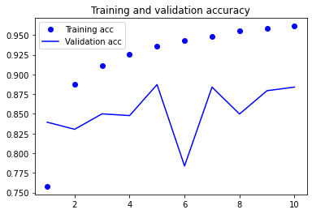

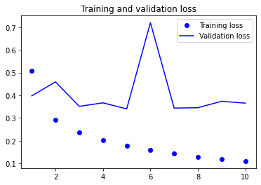

```python
epochs = range(1, len(acc) + 1)

# 정확도
plt.plot(epochs, acc, 'bo', label='Training acc')
plt.plot(epochs, val_acc, 'b', label='Validation acc')
plt.title('Training and validation accuracy')
plt.legend()

#
plt.figure()
plt.plot(epochs, loss, 'bo', label='Training loss')
plt.plot(epochs, val_loss, 'b', label='Validation loss')
plt.title('Training and validation loss')
plt.legend()

plt.show()
```

### 결과 확인

- 좀 더 높은 검증 정확도 달성.
- SimpleRNN 네트워크보다 성능이 더 나은 결과를 보임. LSTM이 그래디언트 소실 문제로부터 덜 영향을 받기 때문.
- 대부분 LSTM이 낫지만, 모든 분야에 나은 것은 아닐수 있다. case by case
  - LSTM이 더 높은 성능을 보이는 곳은 시계열 처리와 자연어 처리문제에 많이 사용됨.
    - 질문-응답(question-answering)과 기계 번역(machine translation)